# BankChurners

**Importing necessary Library Functions**

```python
import pandas as pd
import numpy as np
import matplotlib.pyplot as plt
import seaborn as sns
import warnings
warnings.filterwarnings('ignore')
from sklearn.ensemble import RandomForestClassifier, GradientBoostingClassifier, AdaBoostClassifier
from sklearn.tree import DecisionTreeClassifier
from sklearn.model_selection import RandomizedSearchCV, StratifiedKFold
from sklearn.metrics import classification_report
```

**Import Dataset**

```python
df = pd.read_csv('/content/BankChurners.csv')
```

**First 5 Rows of the Dataset**

```python
df.head()
```

|  | CLIENTNUM | Attrition_Flag | Customer_Age | Gender | Dependent_count | Education_Level | Marital_Status | Income_Category | Card_Category | Months_on_book | ... | Months_Inactive_12_mon | Contacts_Count_12_mon | Credit_Limit | Total_Revolving_Bal | Avg_Open_To_Buy | Total_Amt_Chng_Q4_Q1 | Total_Trans_Amt | Total_Trans_Ct | Total_Ct_Chng_Q4_Q1 | Avg_Utilization_Ratio |
| --- | --- | --- | --- | --- | --- | --- | --- | --- | --- | --- | --- | --- | --- | --- | --- | --- | --- | --- | --- | --- | --- |
| 0 | 768805383 | Existing Customer | 45 | M | 3 | High School | Married | $60K - $80K | Blue | 39 | ... | 1 | 3 | 12691.0 | 777 | 11914.0 | 1.335 | 1144 | 42 | 1.625 | 0.061 |
| 1 | 818770008 | Existing Customer | 49 | F | 5 | Graduate | Single | Less than $40K | Blue | 44 | ... | 1 | 2 | 8256.0 | 864 | 7392.0 | 1.541 | 1291 | 33 | 3.714 | 0.105 |
| 2 | 713982108 | Existing Customer | 51 | M | 3 | Graduate | Married | $80K - $120K | Blue | 36 | ... | 1 | 0 | 3418.0 | 0 | 3418.0 | 2.594 | 1887 | 20 | 2.333 | 0.000 |
| 3 | 769911858 | Existing Customer | 40 | F | 4 | High School | NaN | Less than $40K | Blue | 34 | ... | 4 | 1 | 3313.0 | 2517 | 796.0 | 1.405 | 1171 | 20 | 2.333 | 0.760 |
| 4 | 709106358 | Existing Customer | 40 | M | 3 | Uneducated | Married | $60K - $80K | Blue | 21 | ... | 1 | 0 | 4716.0 | 0 | 4716.0 | 2.175 | 816 | 28 | 2.500 | 0.000 |

5 rows × 21 columns

**Shape of the Data**

```python
df.shape
```

```
(10127, 21)
```

**There are 10127 rows and 21 columns**

**Check for information about dataset**

```python
df.info()
```

```
<class 'pandas.core.frame.DataFrame'>
RangeIndex: 10127 entries, 0 to 10126
Data columns (total 21 columns):
 #   Column                    Non-Null Count  Dtype
---  ------                    --------------  -----
 0   CLIENTNUM                 10127 non-null  int64
 1   Attrition_Flag            10127 non-null  object
 2   Customer_Age              10127 non-null  int64
 3   Gender                    10127 non-null  object
 4   Dependent_count           10127 non-null  int64
 5   Education_Level           8608 non-null   object
 6   Marital_Status            9378 non-null   object
 7   Income_Category           10127 non-null  object
 8   Card_Category             10127 non-null  object
 9   Months_on_book            10127 non-null  int64
 10  Total_Relationship_Count  10127 non-null  int64
 11  Months_Inactive_12_mon    10127 non-null  int64
 12  Contacts_Count_12_mon     10127 non-null  int64
 13  Credit_Limit              10127 non-null  float64
 14  Total_Revolving_Bal       10127 non-null  int64
 15  Avg_Open_To_Buy           10127 non-null  float64
 16  Total_Amt_Chng_Q4_Q1      10127 non-null  float64
 17  Total_Trans_Amt           10127 non-null  int64
 18  Total_Trans_Ct            10127 non-null  int64
 19  Total_Ct_Chng_Q4_Q1       10127 non-null  float64
 20  Avg_Utilization_Ratio     10127 non-null  float64
dtypes: float64(5), int64(10), object(6)
memory usage: 1.6+ MB
```

**The columns are of 10 integer type , 5 float type and 6 object datatypes**

**Check for duplicates**

```python
df.duplicated().sum()
```

```
0
```

**There are no duplicates**

**Checking for null values**

```python
df.isnull().sum()
```

|  | 0 |
| --- | --- |
| CLIENTNUM | 0 |
| Attrition_Flag | 0 |
| Customer_Age | 0 |
| Gender | 0 |
| Dependent_count | 0 |
| Education_Level | 1519 |
| Marital_Status | 749 |
| Income_Category | 0 |
| Card_Category | 0 |
| Months_on_book | 0 |
| Total_Relationship_Count | 0 |
| Months_Inactive_12_mon | 0 |
| Contacts_Count_12_mon | 0 |
| Credit_Limit | 0 |
| Total_Revolving_Bal | 0 |
| Avg_Open_To_Buy | 0 |
| Total_Amt_Chng_Q4_Q1 | 0 |
| Total_Trans_Amt | 0 |
| Total_Trans_Ct | 0 |
| Total_Ct_Chng_Q4_Q1 | 0 |
| Avg_Utilization_Ratio | 0 |

**dtype:** int64

**There are 1519 missing values in Education_Level and 749 Marital_Status**

**Statistical details of the dataset**

```python
df.describe()
```

|  | CLIENTNUM | Customer_Age | Dependent_count | Months_on_book | Total_Relationship_Count | Months_Inactive_12_mon | Contacts_Count_12_mon | Credit_Limit | Total_Revolving_Bal | Avg_Open_To_Buy | Total_Amt_Chng_Q4_Q1 | Total_Trans_Amt | Total_Trans_Ct | Total_Ct_Chng_Q4_Q1 | Avg_Utilization_Ratio |
| --- | --- | --- | --- | --- | --- | --- | --- | --- | --- | --- | --- | --- | --- | --- | --- |
| count | 1.012700e+04 | 10127.000000 | 10127.000000 | 10127.000000 | 10127.000000 | 10127.000000 | 10127.000000 | 10127.000000 | 10127.000000 | 10127.000000 | 10127.000000 | 10127.000000 | 10127.000000 | 10127.000000 | 10127.000000 |
| mean | 7.391776e+08 | 46.325960 | 2.346203 | 35.928409 | 3.812580 | 2.341167 | 2.455317 | 8631.953698 | 1162.814061 | 7469.139637 | 0.759941 | 4404.086304 | 64.858695 | 0.712222 | 0.274894 |
| std | 3.690378e+07 | 8.016814 | 1.298908 | 7.986416 | 1.554408 | 1.010622 | 1.106225 | 9088.776650 | 814.987335 | 9090.685324 | 0.219207 | 3397.129254 | 23.472570 | 0.238086 | 0.275691 |
| min | 7.080821e+08 | 26.000000 | 0.000000 | 13.000000 | 1.000000 | 0.000000 | 0.000000 | 1438.300000 | 0.000000 | 3.000000 | 0.000000 | 510.000000 | 10.000000 | 0.000000 | 0.000000 |
| 25% | 7.130368e+08 | 41.000000 | 1.000000 | 31.000000 | 3.000000 | 2.000000 | 2.000000 | 2555.000000 | 359.000000 | 1324.500000 | 0.631000 | 2155.500000 | 45.000000 | 0.582000 | 0.023000 |
| 50% | 7.179264e+08 | 46.000000 | 2.000000 | 36.000000 | 4.000000 | 2.000000 | 2.000000 | 4549.000000 | 1276.000000 | 3474.000000 | 0.736000 | 3899.000000 | 67.000000 | 0.702000 | 0.176000 |
| 75% | 7.731435e+08 | 52.000000 | 3.000000 | 40.000000 | 5.000000 | 3.000000 | 3.000000 | 11067.500000 | 1784.000000 | 9859.000000 | 0.859000 | 4741.000000 | 81.000000 | 0.818000 | 0.503000 |
| max | 8.283431e+08 | 73.000000 | 5.000000 | 56.000000 | 6.000000 | 6.000000 | 6.000000 | 34516.000000 | 2517.000000 | 34516.000000 | 3.397000 | 18484.000000 | 139.000000 | 3.714000 | 0.999000 |

```python
df.describe().T
```

|  | count | mean | std | min | 25% | 50% | 75% | max |
| --- | --- | --- | --- | --- | --- | --- | --- | --- |
| CLIENTNUM | 10127.0 | 7.391776e+08 | 3.690378e+07 | 708082083.0 | 7.130368e+08 | 7.179264e+08 | 7.731435e+08 | 8.283431e+08 |
| Customer_Age | 10127.0 | 4.632596e+01 | 8.016814e+00 | 26.0 | 4.100000e+01 | 4.600000e+01 | 5.200000e+01 | 7.300000e+01 |
| Dependent_count | 10127.0 | 2.346203e+00 | 1.298908e+00 | 0.0 | 1.000000e+00 | 2.000000e+00 | 3.000000e+00 | 5.000000e+00 |
| Months_on_book | 10127.0 | 3.592841e+01 | 7.986416e+00 | 13.0 | 3.100000e+01 | 3.600000e+01 | 4.000000e+01 | 5.600000e+01 |
| Total_Relationship_Count | 10127.0 | 3.812580e+00 | 1.554408e+00 | 1.0 | 3.000000e+00 | 4.000000e+00 | 5.000000e+00 | 6.000000e+00 |
| Months_Inactive_12_mon | 10127.0 | 2.341167e+00 | 1.010622e+00 | 0.0 | 2.000000e+00 | 2.000000e+00 | 3.000000e+00 | 6.000000e+00 |
| Contacts_Count_12_mon | 10127.0 | 2.455317e+00 | 1.106225e+00 | 0.0 | 2.000000e+00 | 2.000000e+00 | 3.000000e+00 | 6.000000e+00 |
| Credit_Limit | 10127.0 | 8.631954e+03 | 9.088777e+03 | 1438.3 | 2.555000e+03 | 4.549000e+03 | 1.106750e+04 | 3.451600e+04 |
| Total_Revolving_Bal | 10127.0 | 1.162814e+03 | 8.149873e+02 | 0.0 | 3.590000e+02 | 1.276000e+03 | 1.784000e+03 | 2.517000e+03 |
| Avg_Open_To_Buy | 10127.0 | 7.469140e+03 | 9.090685e+03 | 3.0 | 1.324500e+03 | 3.474000e+03 | 9.859000e+03 | 3.451600e+04 |
| Total_Amt_Chng_Q4_Q1 | 10127.0 | 7.599407e-01 | 2.192068e-01 | 0.0 | 6.310000e-01 | 7.360000e-01 | 8.590000e-01 | 3.397000e+00 |
| Total_Trans_Amt | 10127.0 | 4.404086e+03 | 3.397129e+03 | 510.0 | 2.155500e+03 | 3.899000e+03 | 4.741000e+03 | 1.848400e+04 |
| Total_Trans_Ct | 10127.0 | 6.485869e+01 | 2.347257e+01 | 10.0 | 4.500000e+01 | 6.700000e+01 | 8.100000e+01 | 1.390000e+02 |
| Total_Ct_Chng_Q4_Q1 | 10127.0 | 7.122224e-01 | 2.380861e-01 | 0.0 | 5.820000e-01 | 7.020000e-01 | 8.180000e-01 | 3.714000e+00 |
| Avg_Utilization_Ratio | 10127.0 | 2.748936e-01 | 2.756915e-01 | 0.0 | 2.300000e-02 | 1.760000e-01 | 5.030000e-01 | 9.990000e-01 |

**Unique values of categorical columns**

```python
df.select_dtypes(include=['object']).nunique()
```

|  | 0 |
| --- | --- |
| Attrition_Flag | 2 |
| Gender | 2 |
| Education_Level | 6 |
| Marital_Status | 3 |
| Income_Category | 6 |
| Card_Category | 4 |

**dtype:** int64

**Statistical Summary of Categorical Columns**

```python
df.describe(include='object').T
```

|  | count | unique | top | freq |
| --- | --- | --- | --- | --- |
| Attrition_Flag | 10127 | 2 | Existing Customer | 8500 |
| Gender | 10127 | 2 | F | 5358 |
| Education_Level | 8608 | 6 | Graduate | 3128 |
| Marital_Status | 9378 | 3 | Married | 4687 |
| Income_Category | 10127 | 6 | Less than $40K | 3561 |
| Card_Category | 10127 | 4 | Blue | 9436 |

**This shows some of the values are missing in education level and marital status.**

**Convert Object into Categorical**

```python
cat_df = df.select_dtypes(include='object').columns.tolist()
df[cat_df] = df[cat_df].astype('category')
df.info()
```

```
<class 'pandas.core.frame.DataFrame'>
RangeIndex: 10127 entries, 0 to 10126
Data columns (total 21 columns):
 #   Column                    Non-Null Count  Dtype
---  ------                    --------------  -----
 0   CLIENTNUM                 10127 non-null  int64
 1   Attrition_Flag            10127 non-null  category
 2   Customer_Age              10127 non-null  int64
 3   Gender                    10127 non-null  category
 4   Dependent_count           10127 non-null  int64
 5   Education_Level           8608 non-null   category
 6   Marital_Status            9378 non-null   category
 7   Income_Category           10127 non-null  category
 8   Card_Category             10127 non-null  category
 9   Months_on_book            10127 non-null  int64
 10  Total_Relationship_Count  10127 non-null  int64
 11  Months_Inactive_12_mon    10127 non-null  int64
 12  Contacts_Count_12_mon     10127 non-null  int64
 13  Credit_Limit              10127 non-null  float64
 14  Total_Revolving_Bal       10127 non-null  int64
 15  Avg_Open_To_Buy           10127 non-null  float64
 16  Total_Amt_Chng_Q4_Q1      10127 non-null  float64
 17  Total_Trans_Amt           10127 non-null  int64
 18  Total_Trans_Ct            10127 non-null  int64
 19  Total_Ct_Chng_Q4_Q1       10127 non-null  float64
 20  Avg_Utilization_Ratio     10127 non-null  float64
dtypes: category(6), float64(5), int64(10)
memory usage: 1.2 MB
```

**All the object datatype is converted to categorical datatype**

Drop CLIENTNUM

```python
df.drop('CLIENTNUM', axis=1, inplace=True)
```

**Check the details Target variable**

```python
df['Attrition_Flag'].value_counts()
```

| Attrition_Flag | count |
| --- | --- |
| Existing Customer | 8500 |
| Attrited Customer | 1627 |

**dtype:** int64

**The Existing Customer is more than attrited Customer**

**Exploratory Data Analysis** **- Problem definition - Univariate analysis - Bivariate analysis - Use appropriate visualizations to identify the patterns and insights - Key meaningful observations on individual variables and the relationship between variables**

**Problem Statement**

Customers are leaving credit card services that leads to bank loss, so the bank wants to analyze the data of customers and identify the customers who will leave their credit card services and the reason for same. so that the bank could improve upon those areas using Classification Model

**Functions to be defined before Analysis**

```python
# function to plot a boxplot and a histogram along the same scale.


def histogram_boxplot(data, feature, figsize=(12, 7), kde=False, bins=None):
    """
    Boxplot and histogram combined

    data: dataframe
    feature: dataframe column
    figsize: size of figure (default (12,7))
    kde: whether to the show density curve (default False)
    bins: number of bins for histogram (default None)
    """
    f2, (ax_box2, ax_hist2) = plt.subplots(
        nrows=2,  # Number of rows of the subplot grid= 2
        sharex=True,  # x-axis will be shared among all subplots
        gridspec_kw={"height_ratios": (0.25, 0.75)},
        figsize=figsize,
    )  # creating the 2 subplots
    sns.boxplot(
        data=data, x=feature, ax=ax_box2, showmeans=True, color="violet"
    )  # boxplot will be created and a triangle will indicate the mean value of the column
    sns.histplot(
        data=data, x=feature, kde=kde, ax=ax_hist2, bins=bins, palette="winter"
    ) if bins else sns.histplot(
        data=data, x=feature, kde=kde, ax=ax_hist2
    )  # For histogram
    ax_hist2.axvline(
        data[feature].mean(), color="green", linestyle="--"
    )  # Add mean to the histogram
    ax_hist2.axvline(
        data[feature].median(), color="black", linestyle="-"
    )  # Add median to the histogram
```

```python
# function to create labeled barplots


def labeled_barplot(data, feature, perc=False, n=None):
    """
    Barplot with percentage at the top

    data: dataframe
    feature: dataframe column
    perc: whether to display percentages instead of count (default is False)
    n: displays the top n category levels (default is None, i.e., display all levels)
    """

    total = len(data[feature])  # length of the column
    count = data[feature].nunique()
    if n is None:
        plt.figure(figsize=(count + 1, 5))
    else:
        plt.figure(figsize=(n + 1, 5))

    plt.xticks(rotation=90, fontsize=15)
    ax = sns.countplot(
        data=data,
        x=feature,
        palette="Paired",
        order=data[feature].value_counts().index[:n].sort_values(),
    )

    for p in ax.patches:
        if perc == True:
            label = "{:.1f}%".format(
                100 * p.get_height() / total
            )  # percentage of each class of the category
        else:
            label = p.get_height()  # count of each level of the category

        x = p.get_x() + p.get_width() / 2  # width of the plot
        y = p.get_height()  # height of the plot

        ax.annotate(
            label,
            (x, y),
            ha="center",
            va="center",
            size=12,
            xytext=(0, 5),
            textcoords="offset points",
        )  # annotate the percentage

    plt.show()  # show the plot
```

```python
# function to plot stacked bar chart

def stacked_barplot(data, predictor, target):
    """
    Print the category counts and plot a stacked bar chart

    data: dataframe
    predictor: independent variable
    target: target variable
    """
    count = data[predictor].nunique()
    sorter = data[target].value_counts().index[-1]
    tab1 = pd.crosstab(data[predictor], data[target], margins=True).sort_values(
        by=sorter, ascending=False
    )
    print(tab1)
    print("-" * 120)
    tab = pd.crosstab(data[predictor], data[target], normalize="index").sort_values(
        by=sorter, ascending=False
    )
    tab.plot(kind="bar", stacked=True, figsize=(count + 1, 5))
    plt.legend(
        loc="lower left", frameon=False,
    )
    plt.legend(loc="upper left", bbox_to_anchor=(1, 1))
    plt.show()
```

**Univariate analysis**

**Customer Age**

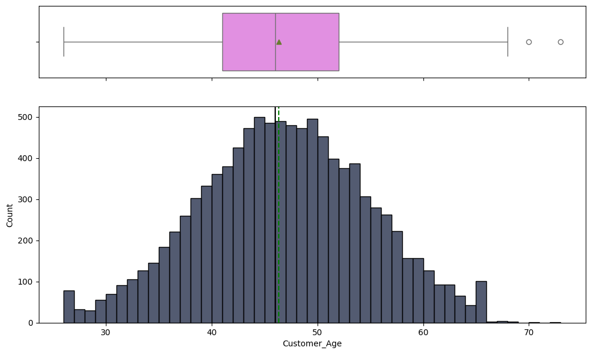

```python
histogram_boxplot(df,'Customer_Age');
```

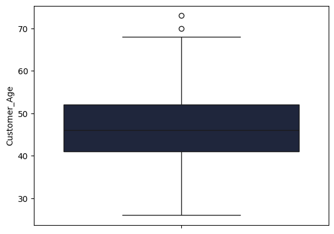

```python
sns.boxplot(df['Customer_Age']);
```

**The Highest population is between 40 to 50 years of age. THis graph shows the normal distribution**

**Check Gender**

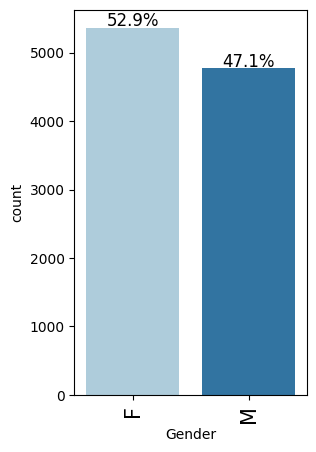

```python
labeled_barplot(df, 'Gender', perc=True)
```

**Female count is high than male count**

**Dependent count**

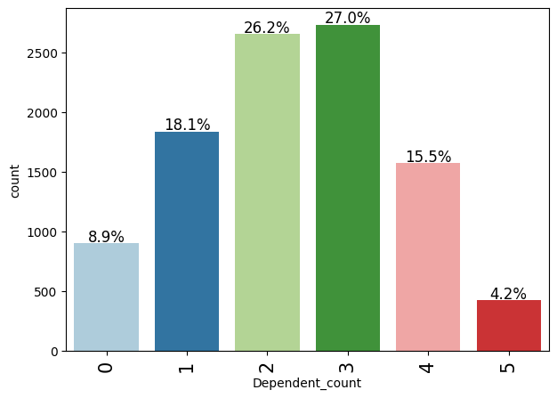

```python
labeled_barplot(df, 'Dependent_count', perc=True)
```

**The number of dependents is maximum with 3 count with 27% and 2 dependent with 26.2%**

**Visualize the Education Level**

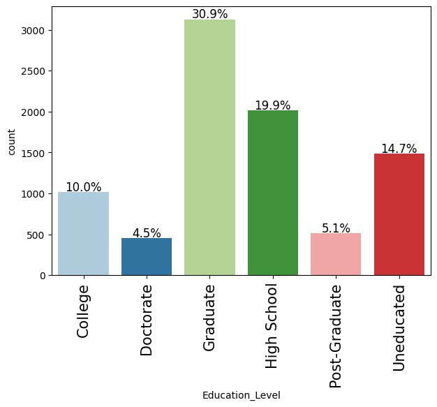

```python
labeled_barplot(df, 'Education_Level', perc=True)
```

**30.9% of customers are Graduates and only 4.5% of customers are doctorates**

**Checking the customer's Marital Status**

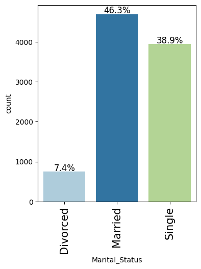

```python
labeled_barplot(df, 'Marital_Status', perc=True)
```

**46.3% of Customers are married**

**Income Category**

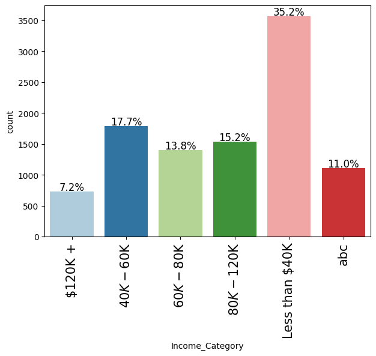

```python
labeled_barplot(df, 'Income_Category', perc=True)
```

**abc cannot be a category so lets treat as nan**

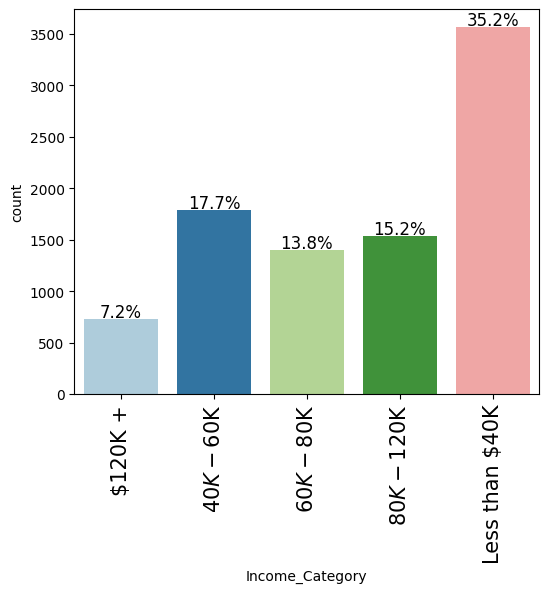

```python
df['Income_Category'].replace('abc', np.nan, inplace=True)
labeled_barplot(df, 'Income_Category', perc=True)
```

**The highest number of credit card customers are the people with income leass than 40k per month**

**Card Category**

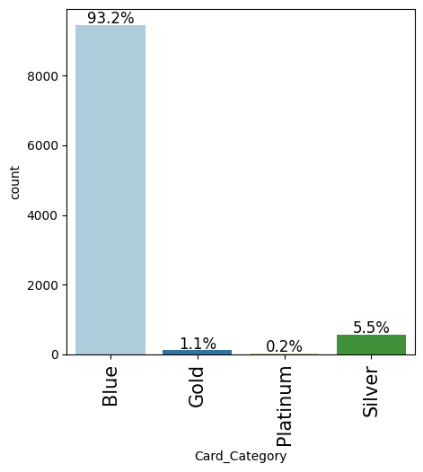

```python
labeled_barplot(df, 'Card_Category', perc=True)
```

```python
df['Card_Category'].value_counts()
```

| Card_Category | count |
| --- | --- |
| Blue | 9436 |
| Silver | 555 |
| Gold | 116 |
| Platinum | 20 |

**dtype:** int64

**Blue Card holders are 93.2% who are highest and the least is Platinum card holders with 0.2%**

**Months on Book**

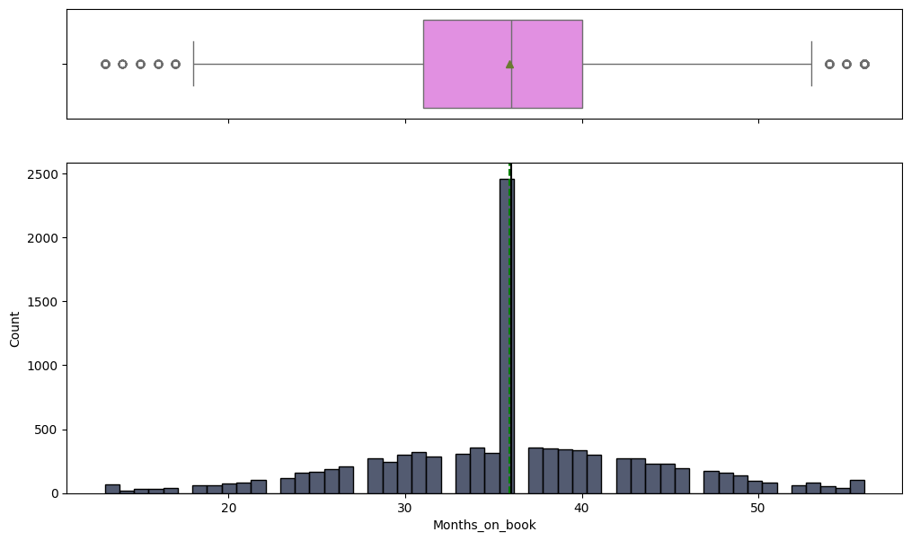

```python
histogram_boxplot(df,'Months_on_book');
```

```python
df['Months_on_book'].describe()
```

|  | Months_on_book |
| --- | --- |
| count | 10127.000000 |
| mean | 35.928409 |
| std | 7.986416 |
| min | 13.000000 |
| 25% | 31.000000 |
| 50% | 36.000000 |
| 75% | 40.000000 |
| max | 56.000000 |

**dtype:** float64

```python
df['Months_on_book'].value_counts(1).head()
```

| Months_on_book | proportion |
| --- | --- |
| 36 | 0.243211 |
| 37 | 0.035351 |
| 34 | 0.034857 |
| 38 | 0.034265 |
| 39 | 0.033672 |

**dtype:** float64

Nearly 24% of people have relationship with the bank for 36 months

**Total_Relationship_Count**

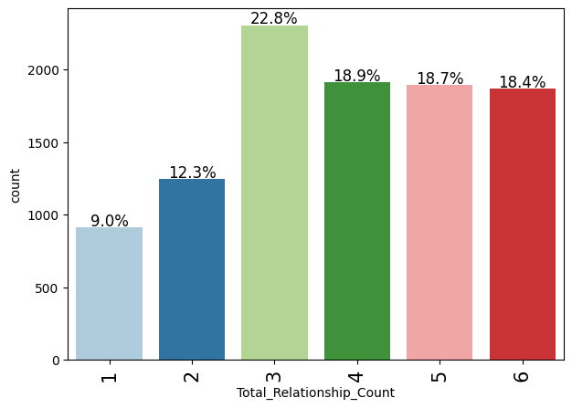

```python
labeled_barplot(df, 'Total_Relationship_Count', perc=True)
```

```python
df['Total_Relationship_Count'].value_counts()
```

| Total_Relationship_Count | count |
| --- | --- |
| 3 | 2305 |
| 4 | 1912 |
| 5 | 1891 |
| 6 | 1866 |
| 2 | 1243 |
| 1 | 910 |

**dtype:** int64

**The maximum number of products held by customer is 3 folled by 4 and the least is 1**

**Total Number of months they are inactive**

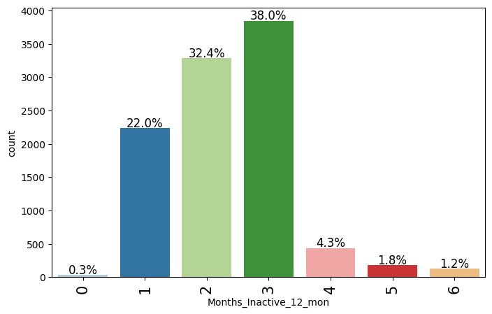

```python
labeled_barplot(df, 'Months_Inactive_12_mon', perc=True)
```

**Maximum the months they are inactive is 3, 38% and the least is 0**

**Credit_Limit**

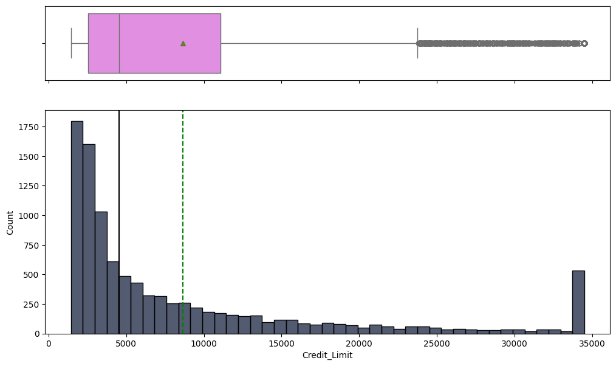

```python
histogram_boxplot(df,'Credit_Limit');
```

**Total_Revolving_Bal**

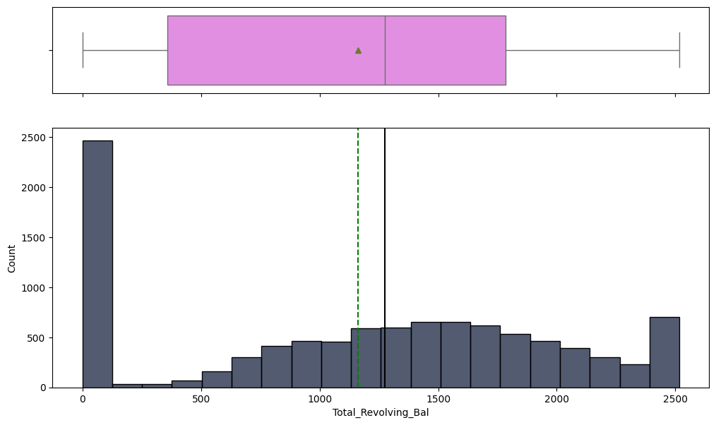

```python
histogram_boxplot(df,'Total_Revolving_Bal');
```

**50% People have revolving balance of 1250 and and mean around 1100**

**Many pay their credit bills regularly with 0 pending**

**Avg_Open_To_Buy**

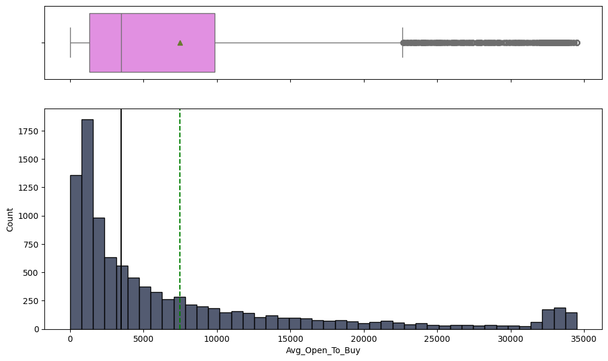

```python
histogram_boxplot(df,'Avg_Open_To_Buy');
```

**This wide range is based on type of credit card people hold.**

**Total_Amt_Chng_Q4_Q1**

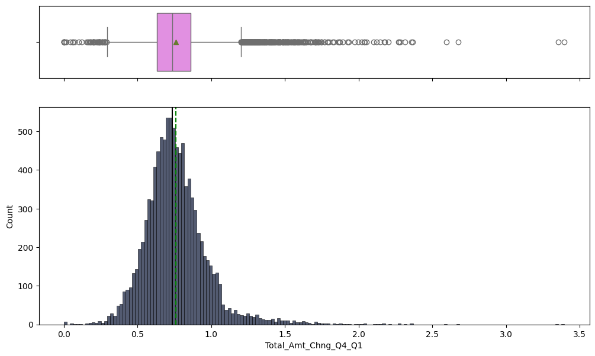

```python
histogram_boxplot(df, 'Total_Amt_Chng_Q4_Q1');
```

**It shows a normal distribution but at the same time it has outliers on both sides and it has more outliers on right side**

**The mean and median are much closer to each other around 0.7**

**Total_Trans_Amt**

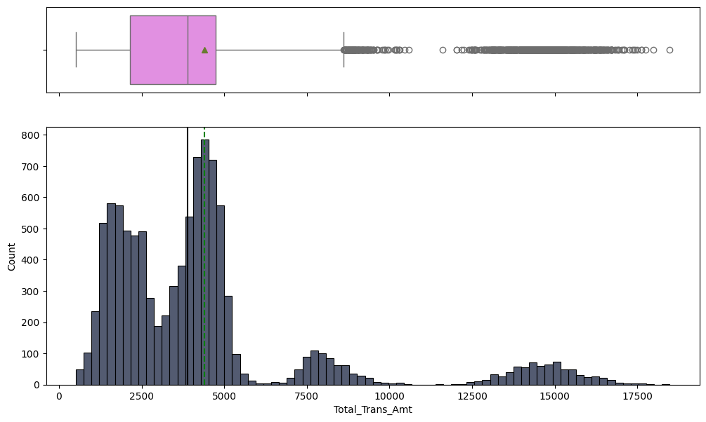

```python
histogram_boxplot(df, 'Total_Trans_Amt');
```

**It is heavily right skewed.**

**Every customer has used their card**

**Total_Trans_Ct**

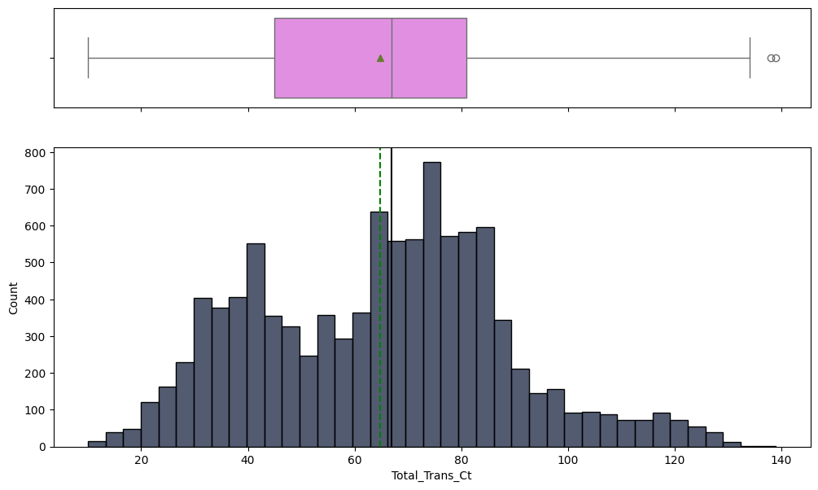

```python
histogram_boxplot(df, 'Total_Trans_Ct');
```

**Mean and median are closer with less outliers on rightside**

**Total_Ct_Chng_Q4_Q1**

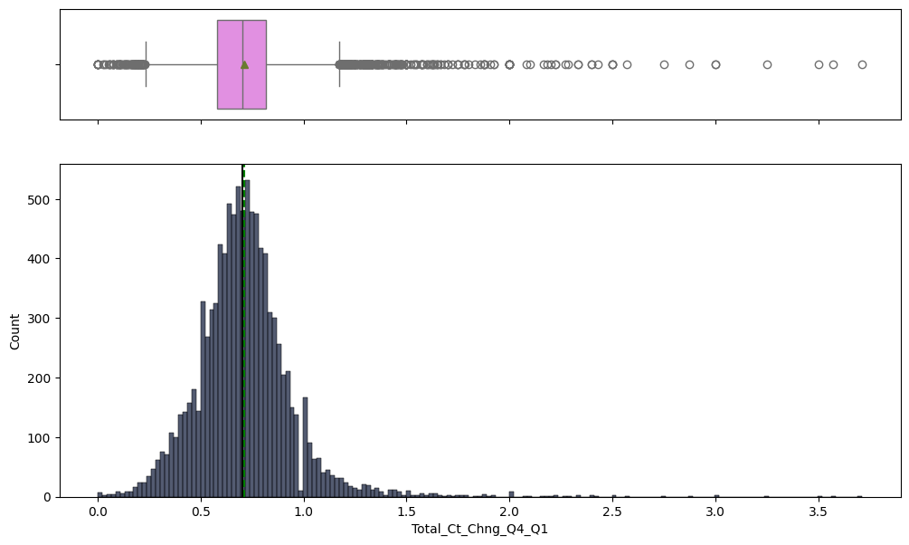

```python
histogram_boxplot(df, 'Total_Ct_Chng_Q4_Q1');
```

**There are many outliers in rightside and it is highly right-skewed**

**Avg_Utilization_Ratio**

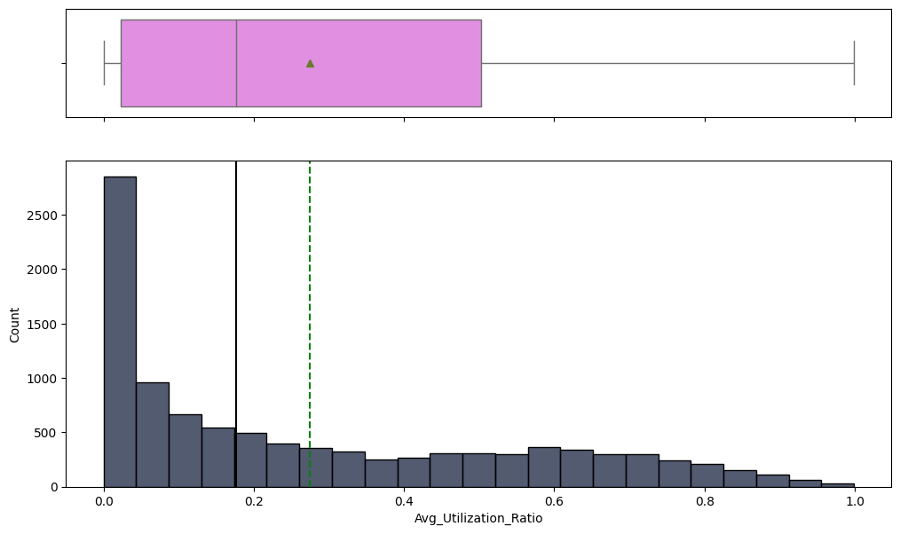

```python
histogram_boxplot(df, 'Avg_Utilization_Ratio');
```

**The graph is right skewed but has no outliers with the mean 0.27 and median 0.17**

**Bivariate Analysis**

**Find the Inter-Dependencies between the Features**

**Target Vs All Numerical Columns**

```python
# Below code plots box charts for each numerical feature by each type of Personal Loan (0: Not Borrowed, 1: Borroed)
def box_by_target(data: pd.DataFrame, numeric_columns, target, include_outliers):
    """
    The function takes a category column, target column, and whether to include outliers or not as input
    and plots bar chart with percentages on top of each bar

    Usage:
    ------

    perc_on_bar(['age'], 'prodtaken', True)
    """
    subplot_cols = 2
    subplot_rows = int(len(numeric_columns) / 2 + 1)
    plt.figure(figsize=(16, 3 * subplot_rows))
    for i, col in enumerate(numeric_columns):
        plt.subplot(8, 2, i + 1)
        sns.boxplot(
            data=data,
            x=target,
            y=col,
            orient="vertical",
            palette="Blues",
            showfliers=include_outliers,
        )
        plt.tight_layout()
        plt.title(str(i + 1) + ": " + target + " vs. " + col, color="black")
```

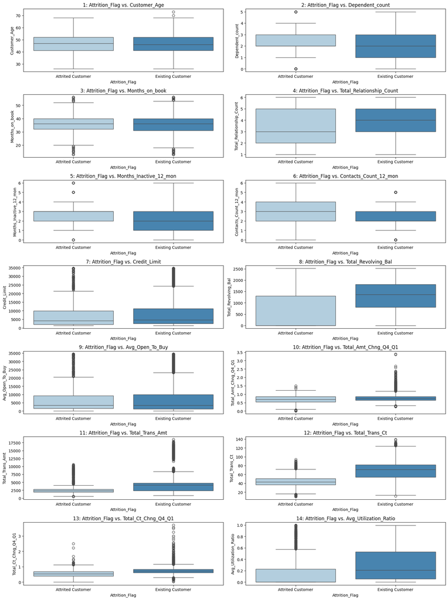

```python
numeric_columns = df.select_dtypes(exclude="category").columns.tolist()
target_variable = "Attrition_Flag"
box_by_target(df, numeric_columns, target_variable, True)
```

Without Outliers

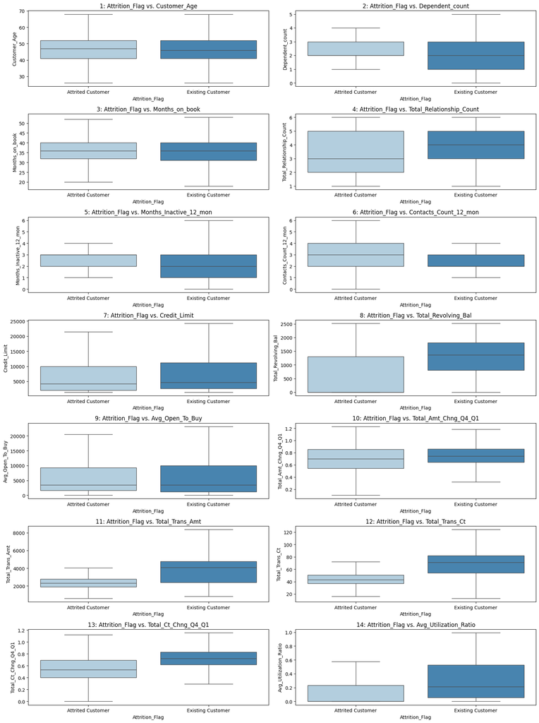

```python
box_by_target(df, numeric_columns, target_variable, False)
```

- Avg_Utilization_Ratio for the existing customer is Higher than Attrited custome
- Ratio of Number of times the customer being contacted over 4th quarted to 1st quarter is also high in Existing customer
- Total transaction count over 12 months is also high in existing customer
- The contact count o customer is higher as the bank as contacted many times the attrited ones than the exisiting ones

**Target vs Categorical variables**

```python
# Create a function that returns a Pie chart and a Bar Graph for the categorical variables:
def categorical_view(df: pd.DataFrame, x, target):
    """
    Function to create a Bar chart and a Pie chart for categorical variables.
    """
    from matplotlib import cm

    color1 = cm.inferno(np.linspace(0.4, 0.8, 30))
    color2 = cm.viridis(np.linspace(0.4, 0.8, 30))
    sns.set_palette("cubehelix")
    fig, ax = plt.subplots(1, 2, figsize=(16, 4))

    """
    Draw a Pie Chart on first subplot.
    """
    s = df.groupby(x).size()

    mydata_values = s.values.tolist()
    mydata_index = s.index.tolist()

    def func(pct, allvals):
        absolute = int(pct / 100.0 * np.sum(allvals))
        return "{:.1f}%\n({:d})".format(pct, absolute)
    wedges, texts, autotexts = ax[0].pie(
        mydata_values,
        autopct=lambda pct: func(pct, mydata_values),
        textprops=dict(color="w"),
    )

    ax[0].legend(
        wedges,
        mydata_index,
        title=x.capitalize(),
        loc="center left",
        bbox_to_anchor=(1, 0, 0.5, 1),
    )

    plt.setp(autotexts, size=12)

    ax[0].set_title(f"{x.capitalize()} Pie Chart")

    """
    Draw a Bar Graph on second subplot.
    """

    df = pd.pivot_table(
        df, index=[x], columns=[target], values=["Credit_Limit"], aggfunc=len
    )
    labels = df.index.tolist()
    no = df.values[:, 1].tolist()
    yes = df.values[:, 0].tolist()

    l = np.arange(len(labels))  # the label locations
    width = 0.35  # the width of the bars

    rects1 = ax[1].bar(
        l - width / 2, no, width, label="Existing Customer", color=color1
    )
    rects2 = ax[1].bar(
        l + width / 2, yes, width, label="Attrited Customer", color=color2
    )

    # Add some text for labels, title and custom x-axis tick labels, etc.
    ax[1].set_ylabel("Scores")
    ax[1].set_title(f"{x.capitalize()} Bar Graph")
    ax[1].set_xticks(l)
    ax[1].set_xticklabels(labels)
    ax[1].legend()
    def autolabel(rects):

        """Attach a text label above each bar in *rects*, displaying its height."""

        for rect in rects:
            height = rect.get_height()
            ax[1].annotate(
                "{}".format(height),
                xy=(rect.get_x() + rect.get_width() / 2, height),
                xytext=(0, 3),  # 3 points vertical offset
                textcoords="offset points",
                fontsize="medium",
                ha="center",
                va="bottom",
            )

    autolabel(rects1)
    autolabel(rects2)

    fig.tight_layout()
    plt.show()

    """
    Draw a Stacked Bar Graph on bottom.
    """
    sns.set(palette="tab10")
    tab = pd.crosstab(df[x], df[target], normalize="index")

    tab.plot.bar(stacked=True, figsize=(16, 3))
    plt.title(x.capitalize() + " Stacked Bar Plot")
    plt.legend(loc="upper right", bbox_to_anchor=(0, 1))
    plt.show()
```

```python
# Create a function that returns a Pie chart and a Bar Graph for the categorical variables:
def categorical_view(df: pd.DataFrame, x, target):
    """
    Function to create a Bar chart and a Pie chart for categorical variables.
    """
    from matplotlib import cm

    color1 = cm.inferno(np.linspace(0.4, 0.8, 30))
    color2 = cm.viridis(np.linspace(0.4, 0.8, 30))
    sns.set_palette("cubehelix")
    fig, ax = plt.subplots(1, 2, figsize=(16, 4))

    """
    Draw a Pie Chart on first subplot.
    """
    s = df.groupby(x).size()

    mydata_values = s.values.tolist()
    mydata_index = s.index.tolist()

    def func(pct, allvals):
        absolute = int(pct / 100.0 * np.sum(allvals))
        return "{:.1f}%\n({:d})".format(pct, absolute)
    wedges, texts, autotexts = ax[0].pie(
        mydata_values,
        autopct=lambda pct: func(pct, mydata_values),
        textprops=dict(color="w"),
    )

    ax[0].legend(
        wedges,
        mydata_index,
        title=x.capitalize(),
        loc="center left",
        bbox_to_anchor=(1, 0, 0.5, 1),
    )

    plt.setp(autotexts, size=12)

    ax[0].set_title(f"{x.capitalize()} Pie Chart")

    """
    Draw a Bar Graph on second subplot.
    """

    # Use a different variable name to avoid overwriting the original DataFrame
    pivot_df = pd.pivot_table(
        df, index=[x], columns=[target], values=["Credit_Limit"], aggfunc=len
    )
    labels = pivot_df.index.tolist()  # Access index from pivot_df
    no = pivot_df.values[:, 1].tolist()  # Access values from pivot_df
    yes = pivot_df.values[:, 0].tolist()  # Access values from pivot_df

    l = np.arange(len(labels))  # the label locations
    width = 0.35  # the width of the bars

    rects1 = ax[1].bar(
        l - width / 2, no, width, label="Existing Customer", color=color1
    )
    rects2 = ax[1].bar(
        l + width / 2, yes, width, label="Attrited Customer", color=color2
    )

    # Add some text for labels, title and custom x-axis tick labels, etc.
    ax[1].set_ylabel("Scores")
    ax[1].set_title(f"{x.capitalize()} Bar Graph")
    ax[1].set_xticks(l)
    ax[1].set_xticklabels(labels)
    ax[1].legend()
    def autolabel(rects):
        """Attach a text label above each bar in
        *rects*, displaying its height."""
```

**Categorical variables Vs Target**

**Gender Vs Target**

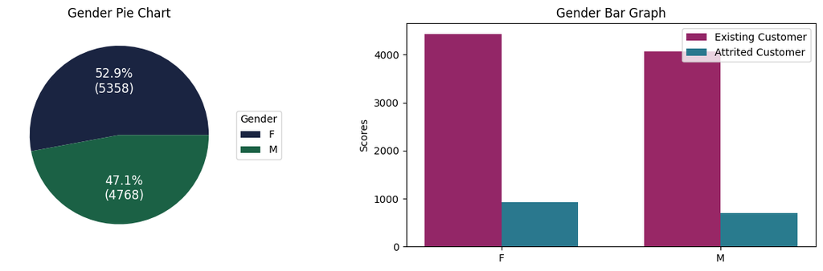

```python
categorical_view(df, 'Gender', 'Attrition_Flag');
```

**Gender doesnot impact the Attrition flag**

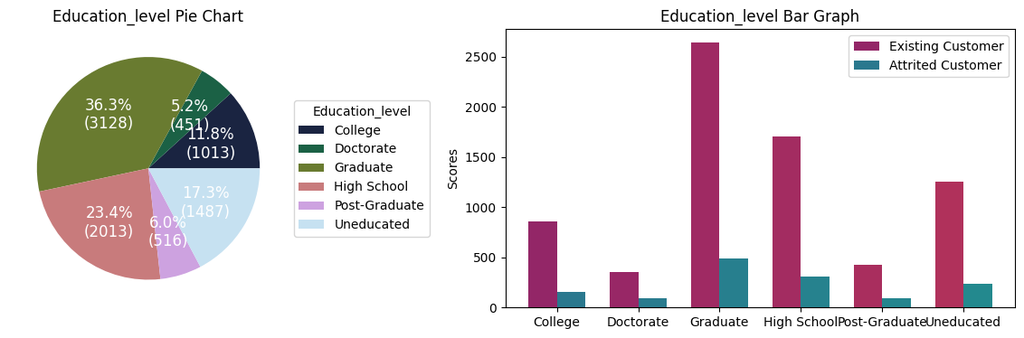

```python
categorical_view(df, 'Education_Level', 'Attrition_Flag');
```

**Customers who are Graduate and did High school own credit card in majority**

**the people who did masters and doctorate own less credit card. Maybe they are much aware of the demerits of the credit card**

**Income Vs Target**

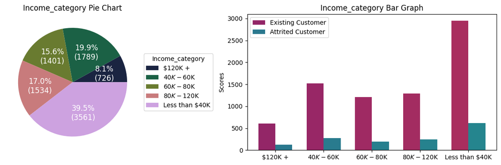

```python
categorical_view(df, 'Income_Category', 'Attrition_Flag');
```

**Income doesnot impact the attrition**

**Card Category Vs Target**

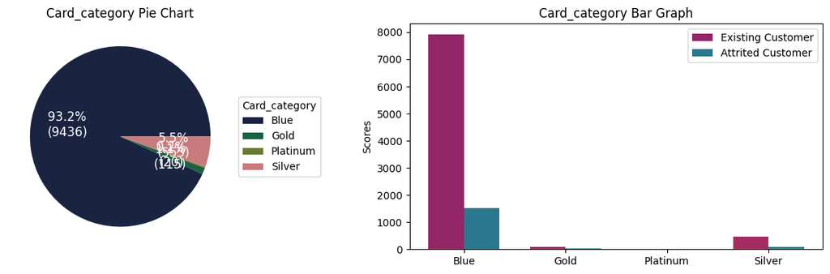

```python
categorical_view(df, 'Card_Category', 'Attrition_Flag');
```

**Platinum card holders show more withdraw of credit cards compared to others.**

**Platinum card impacts attrition**

**Multivariate Analysis**

**Heatmap to check Correlation**

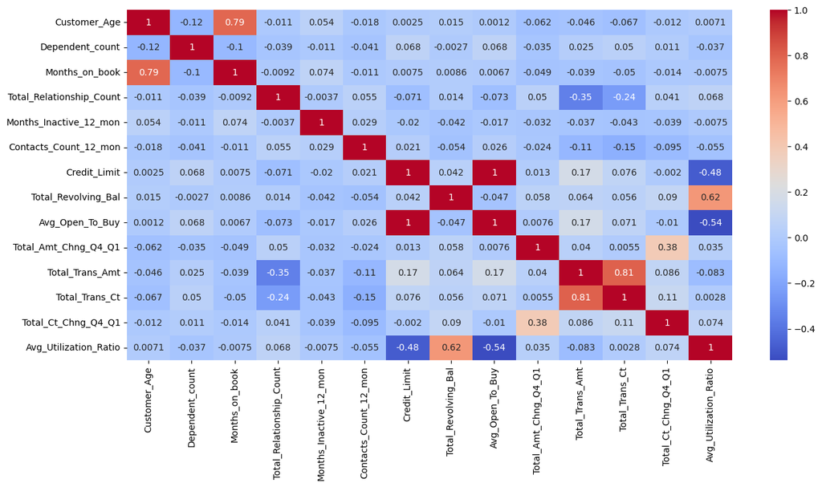

```python
plt.figure(figsize=(15, 7))
sns.heatmap(df.corr(numeric_only= True), annot = True, cmap = 'coolwarm')
plt.show()
```

**1. There is high correlation between customer age and Months on book, Avg open to buy and credit limit, Average utilization ratio and total revolving balance, total transaction amount and total transaction contact**

**Data Preprocessing- Missing Value Treatment (with rationale if needed) - Outlier Detection and Treatment (with rationale if needed) - Feature Engineering (with rationale if needed) - Train-test split - Ensure no data leakage**

**Steps Involved in Data Preprocessing**

Split data into independant and dependant variable

1. Split data into Train and Test
2. Split into train, validation and test
3. Outlier Treatment
4. Missing value treatment
5. Encoding

**Split data into Train and Test**

```python
from sklearn.model_selection import train_test_split
```

```python
df["Attrition_Flag"].replace("Existing Customer", 0, inplace=True)
df["Attrition_Flag"].replace("Attrited Customer", 1, inplace=True)
```

**Outlier Treatment**

```python
# Fetch all numerical columns
numerical_cols = df.select_dtypes(include=['number']).columns.tolist()

# To find the 25th percentile and 75th percentile.
Q1 = df[numerical_cols].quantile(0.25)
Q3 = df[numerical_cols].quantile(0.75)

IQR = Q3 - Q1  # Inter Quantile Range (75th perentile - 25th percentile)

lower = (
    Q1 - 1.5 * IQR
)  # Finding lower and upper bounds for all values. All values outside these bounds are outliers
upper = Q3 + 1.5 * IQR
```

```python
(
    (df.select_dtypes(include=["float64", "int64"]) < lower)
    | (df.select_dtypes(include=["float64", "int64"]) > upper)
).sum() / len(df) * 100
```

|  | 0 |
| --- | --- |
| Customer_Age | 0.019749 |
| Dependent_count | 0.000000 |
| Months_on_book | 3.811593 |
| Total_Relationship_Count | 0.000000 |
| Months_Inactive_12_mon | 3.268490 |
| Contacts_Count_12_mon | 6.211119 |
| Credit_Limit | 9.716599 |
| Total_Revolving_Bal | 0.000000 |
| Avg_Open_To_Buy | 9.509233 |
| Total_Amt_Chng_Q4_Q1 | 3.910339 |
| Total_Trans_Amt | 8.847635 |
| Total_Trans_Ct | 0.019749 |
| Total_Ct_Chng_Q4_Q1 | 3.890590 |
| Avg_Utilization_Ratio | 0.000000 |

**dtype:** float64

**Missing Value Treatment**

Check the number of NAN values in each dataframe

```python
df1 = df.copy()
```

```python
df1["Income_Category"].replace("abc", np.nan, inplace=True)
```

```python
df1.isna().sum()
```

|  | 0 |
| --- | --- |
| Attrition_Flag | 0 |
| Customer_Age | 0 |
| Gender | 0 |
| Dependent_count | 0 |
| Education_Level | 1519 |
| Marital_Status | 749 |
| Income_Category | 1112 |
| Card_Category | 0 |
| Months_on_book | 0 |
| Total_Relationship_Count | 0 |
| Months_Inactive_12_mon | 0 |
| Contacts_Count_12_mon | 0 |
| Credit_Limit | 0 |
| Total_Revolving_Bal | 0 |
| Avg_Open_To_Buy | 0 |
| Total_Amt_Chng_Q4_Q1 | 0 |
| Total_Trans_Amt | 0 |
| Total_Trans_Ct | 0 |
| Total_Ct_Chng_Q4_Q1 | 0 |
| Avg_Utilization_Ratio | 0 |

**dtype:** int64

**The abc is replaced so we have na in educational level, income category and marital status**

```python
from sklearn.impute import SimpleImputer
imputer = SimpleImputer(strategy="most_frequent")
```

```python
X = df1.drop(["Attrition_Flag"], axis=1)
y = df1["Attrition_Flag"]
```

**Splitting data into dependent and independent variable**

```python
# Splitting data into training, validation and test set:
# first we split data into 2 parts, say temporary and test

X_temp, X_test, y_temp, y_test = train_test_split(
    X, y, test_size=0.2, random_state=1, stratify=y
)

# then we split the temporary set into train and validation

X_train, X_val, y_train, y_val = train_test_split(
    X_temp, y_temp, test_size=0.25, random_state=1, stratify=y_temp
)
print(X_train.shape, X_val.shape, X_test.shape)
```

```
(6075, 19) (2026, 19) (2026, 19)
```

**This is the shape of train,test and val of the new dataset with 6075 rows and 19 columns for train, 2026 rows and 19 columns for validation and 2026 rows and 19 columns for testing**

```python
reqd_col_for_impute = ["Education_Level", "Marital_Status", "Income_Category"]
```

**Creating an imputer to impute values**

```python
# Fit and transform the train data
X_train[reqd_col_for_impute] = imputer.fit_transform(X_train[reqd_col_for_impute])

# Transform the validation data
X_val[reqd_col_for_impute] = imputer.transform(X_val[reqd_col_for_impute])

# Transform the test data
X_test[reqd_col_for_impute] = imputer.transform(X_test[reqd_col_for_impute])
```

```python
print(X_train.isnull().sum())
print('-'*50)
print(X_val.isnull().sum())
print('-'*50)
print(X_test.isnull().sum())
```

```
Customer_Age                0
Gender                      0
Dependent_count             0
Education_Level             0
Marital_Status              0
Income_Category             0
Card_Category               0
Months_on_book              0
Total_Relationship_Count    0
Months_Inactive_12_mon      0
Contacts_Count_12_mon       0
Credit_Limit                0
Total_Revolving_Bal         0
Avg_Open_To_Buy             0
Total_Amt_Chng_Q4_Q1        0
Total_Trans_Amt             0
Total_Trans_Ct              0
Total_Ct_Chng_Q4_Q1         0
Avg_Utilization_Ratio       0
dtype: int64
--------------------------------------------------
Customer_Age                0
Gender                      0
Dependent_count             0
Education_Level             0
Marital_Status              0
Income_Category             0
Card_Category               0
Months_on_book              0
Total_Relationship_Count    0
Months_Inactive_12_mon      0
Contacts_Count_12_mon       0
Credit_Limit                0
Total_Revolving_Bal         0
Avg_Open_To_Buy             0
Total_Amt_Chng_Q4_Q1        0
Total_Trans_Amt             0
Total_Trans_Ct              0
Total_Ct_Chng_Q4_Q1         0
Avg_Utilization_Ratio       0
dtype: int64
--------------------------------------------------
Customer_Age                0
Gender                      0
Dependent_count             0
Education_Level             0
Marital_Status              0
Income_Category             0
Card_Category               0
Months_on_book              0
Total_Relationship_Count    0
Months_Inactive_12_mon      0
Contacts_Count_12_mon       0
Credit_Limit                0
Total_Revolving_Bal         0
Avg_Open_To_Buy             0
Total_Amt_Chng_Q4_Q1        0
Total_Trans_Amt             0
Total_Trans_Ct              0
Total_Ct_Chng_Q4_Q1         0
Avg_Utilization_Ratio       0
dtype: int64
```

**These are the missing values in Train, validation and test dataset**

```python
cols = X_train.select_dtypes(include=["object", "category"])
for i in cols.columns:
    print(X_train[i].value_counts())
    print("*" * 30)
```

```
Gender
F    3193
M    2882
Name: count, dtype: int64
Education_Level
Graduate         2782
High School      1228
Uneducated        881
College           618
Post-Graduate     312
Doctorate         254
Name: count, dtype: int64
Marital_Status
Married     3276
Single      2369
Divorced     430
Name: count, dtype: int64
Income_Category
Less than $40K    2783
$40K - $60K       1059
$80K - $120K       953
$60K - $80K        831
$120K +            449
Name: count, dtype: int64
Card_Category
Blue        5655
Silver       339
Gold          69
Platinum      12
Name: count, dtype: int64
```

```python
cols = X_val.select_dtypes(include=["object", "category"])
for i in cols.columns:
    print(X_val[i].value_counts())
    print("*" * 30)
```

```
Gender
F    1095
M     931
Name: count, dtype: int64
Education_Level
Graduate         917
High School      404
Uneducated       306
College          199
Post-Graduate    101
Doctorate         99
Name: count, dtype: int64
Marital_Status
Married     1100
Single       770
Divorced     156
Name: count, dtype: int64
Income_Category
Less than $40K    957
$40K - $60K       361
$80K - $120K      293
$60K - $80K       279
$120K +           136
Name: count, dtype: int64
Card_Category
Blue        1905
Silver        97
Gold          21
Platinum       3
Name: count, dtype: int64
```

```python
cols = X_test.select_dtypes(include=["object", "category"])
for i in cols.columns:
    print(X_train[i].value_counts())
    print("*" * 30)
```

```
Gender
F    3193
M    2882
Name: count, dtype: int64
Education_Level
Graduate         2782
High School      1228
Uneducated        881
College           618
Post-Graduate     312
Doctorate         254
Name: count, dtype: int64
Marital_Status
Married     3276
Single      2369
Divorced     430
Name: count, dtype: int64
Income_Category
Less than $40K    2783
$40K - $60K       1059
$80K - $120K       953
$60K - $80K        831
$120K +            449
Name: count, dtype: int64
Card_Category
Blue        5655
Silver       339
Gold          69
Platinum      12
Name: count, dtype: int64
```

**Encoding the Categorical columns**

```python
# drop the first of each encoded column to reduce dataframe and perform encoding for train, val and test for categorial columns
X_train = pd.get_dummies(X_train, drop_first=True)
X_val = pd.get_dummies(X_val, drop_first=True)
X_test = pd.get_dummies(X_test, drop_first=True)
```

```python
print(X_train.shape, X_val.shape, X_test.shape)
```

```
(6075, 29) (2026, 29) (2026, 29)
```

```python
X_train.head()
```

|  | Customer_Age | Dependent_count | Months_on_book | Total_Relationship_Count | Months_Inactive_12_mon | Contacts_Count_12_mon | Credit_Limit | Total_Revolving_Bal | Avg_Open_To_Buy | Total_Amt_Chng_Q4_Q1 | ... | Education_Level_Uneducated | Marital_Status_Married | Marital_Status_Single | Income_Category_$40K - $60K | Income_Category_$60K - $80K | Income_Category_$80K - $120K | Income_Category_Less than $40K | Card_Category_Gold | Card_Category_Platinum | Card_Category_Silver |
| --- | --- | --- | --- | --- | --- | --- | --- | --- | --- | --- | --- | --- | --- | --- | --- | --- | --- | --- | --- | --- | --- |
| 800 | 40 | 2 | 21 | 6 | 4 | 3 | 20056.0 | 1602 | 18454.0 | 0.466 | ... | False | False | True | False | False | False | False | False | False | False |
| 498 | 44 | 1 | 34 | 6 | 2 | 0 | 2885.0 | 1895 | 990.0 | 0.387 | ... | False | True | False | False | False | False | True | False | False | False |
| 4356 | 48 | 4 | 36 | 5 | 1 | 2 | 6798.0 | 2517 | 4281.0 | 0.873 | ... | False | True | False | False | False | True | False | False | False | False |
| 407 | 41 | 2 | 36 | 6 | 2 | 0 | 27000.0 | 0 | 27000.0 | 0.610 | ... | False | True | False | False | True | False | False | False | False | True |
| 8728 | 46 | 4 | 36 | 2 | 2 | 3 | 15034.0 | 1356 | 13678.0 | 0.754 | ... | False | False | False | True | False | False | False | False | False | True |

5 rows × 29 columns

```python
from sklearn.preprocessing import StandardScaler

# Identify numerical features
numerical_features = X_train.select_dtypes(include='number').columns

# Initialize the scaler
scaler = StandardScaler()

# Fit the scaler on the training data and transform it
X_train[numerical_features] = scaler.fit_transform(X_train[numerical_features])

# Use the same scaler to transform validation and test data
X_val[numerical_features] = scaler.transform(X_val[numerical_features])
X_test[numerical_features] = scaler.transform(X_test[numerical_features])

# Check the scaled data
print("Scaled X_train:")
print(X_train.head())

print("Scaled X_val:")
print(X_val.head())

print("Scaled X_test:")
print(X_test.head())
```

```
Scaled X_train:
      Customer_Age  Dependent_count  Months_on_book  Total_Relationship_Count  \
800      -0.787094        -0.262487       -1.884139                  1.393287
498      -0.288946        -1.030603       -0.248364                  1.393287
4356      0.209202         1.273745        0.003293                  0.751621
407      -0.662557        -0.262487        0.003293                  1.393287
8728     -0.039872         1.273745        0.003293                 -1.173378

      Months_Inactive_12_mon  Contacts_Count_12_mon  Credit_Limit  \
800                 1.641770               0.495012      1.253651
498                -0.336953              -2.209303     -0.632908
4356               -1.326315              -0.406426     -0.202991
407                -0.336953              -2.209303      2.016580
8728               -0.336953               0.495012      0.701889

```

[output cut: 159 more lines]

**Preprocessing is completed**

**Define the functions for different metrics on the train and test set and a function to show confusion matrix**

```python
# defining a function to compute different metrics to check performance of a classification model built using sklearn
def model_performance_classification_sklearn(model, predictors, target):
    """
    Function to compute different metrics to check classification model performance

    model: classifier
    predictors: independent variables
    target: dependent variable
    """

    # predicting using the independent variables
    pred = model.predict(predictors)

    acc = accuracy_score(target, pred)  # to compute Accuracy
    recall = recall_score(target, pred)  # to compute Recall
    precision = precision_score(target, pred)  # to compute Precision
    f1 = f1_score(target, pred)  # to compute F1-score

    # creating a dataframe of metrics
    df_perf = pd.DataFrame(
        {"Accuracy": acc, "Recall": recall, "Precision": precision, "F1": f1,},
        index=[0],
    )

    return df_perf
```

```python
def confusion_matrix_sklearn(model, predictors, target):
    """
    To plot the confusion_matrix with percentages

    model: classifier
    predictors: independent variables
    target: dependent variable
    """
    y_pred = model.predict(predictors)
    cm = confusion_matrix(target, y_pred)
    labels = np.asarray(
        [
            ["{0:0.0f}".format(item) + "\n{0:.2%}".format(item / cm.flatten().sum())]
            for item in cm.flatten()
        ]
    ).reshape(2, 2)

    plt.figure(figsize=(6, 4))
    sns.heatmap(cm, annot=labels, fmt="")
    plt.ylabel("True label")
    plt.xlabel("Predicted label")
```

**Model Building**

**Model Building - Original Data- Choose the metric to optimize for the problem - Build 5 models (from decision trees, bagging and boosting methods) - Check and comment on model performance across different metrics**

```python
from sklearn.ensemble import BaggingClassifier, RandomForestClassifier, AdaBoostClassifier, GradientBoostingClassifier
from xgboost import XGBClassifier # Assuming you are using XGBoost
from sklearn.metrics import accuracy_score, recall_score, precision_score, f1_score, confusion_matrix
from sklearn.metrics import make_scorer
#from imblearn.over_sampling import SMOTE # Import SMOTE if needed
models = []  # Empty list to store all the models.

# Appending models into the list.
models.append(("Bagging", BaggingClassifier(random_state=1)))
models.append(("Random forest", RandomForestClassifier(random_state=1)))
models.append(("AdaBoost", AdaBoostClassifier(random_state=1)))
models.append(("GradientBoost", GradientBoostingClassifier(random_state=1)))
models.append(("XGBoost", XGBClassifier(random_state=1)))

# Printing model performance scores on training data.
print("\n" "Training Performance:" "\n")
for name, model in models:
    model.fit(X_train, y_train)
    scores = precision_score(y_train, model.predict(X_train))
    print("{}: {}".format(name, scores))

# Printing model performance scores on validation data.
print("\n" "Validation Performance:" "\n")
for name, model in models:
    model.fit(X_train, y_train)
    scores_val = precision_score(y_val, model.predict(X_val))
    print("{}: {}".format(name, scores_val))
```

```
Training Performance:

Bagging: 0.9968911917098445
Random forest: 1.0
AdaBoost: 0.8996655518394648
GradientBoost: 0.9520624303232998
XGBoost: 1.0

Validation Performance:

Bagging: 0.9044368600682594
Random forest: 0.9157894736842105
AdaBoost: 0.9055374592833876
GradientBoost: 0.9364548494983278
XGBoost: 0.91875
```

**The models Considered were Bagging, Adaboost, Gradient Boosting, XGBoost Classifier and Random Forest**

**Gradient Boost performs well in Validation with 93%**

**Check and comment on model performance across different metrics**

**Gradient Boost performs better with 93.6%**

**True Positive** is Attrited Customer and found as attrited customer itself **False postive** is Existing customer found as Attrited customer **False Negative** is Attrited customer found as Existing Customer **False Positive** is existing customer found as existing customer.

**Since False Positive should be given more importance i observe Precision**

**Gradient Boost gives better value in precision for validation**

**Model Building - Oversampled data- Oversample the train data - Build 5 models (from decision trees, bagging and boosting methods) - Check and comment on model performance across different metrics**

**SMOTE for OverSampling Data**

```python
!pip install imbalanced-learn # Install the necessary library
from imblearn.over_sampling import SMOTE # Import the SMOTE class
# Synthetic Minority Over Sampling Technique.
sm = SMOTE(sampling_strategy=1, k_neighbors=5, random_state=1)
X_train_over, y_train_over = sm.fit_resample(X_train, y_train)
```

```python
models_over = []  # Empty list to store all the models.

# Appending models into the list
models_over.append(("Bagging", BaggingClassifier(random_state=1)))
models_over.append(("Random forest", RandomForestClassifier(random_state=1)))
models_over.append(("AdaBoost", AdaBoostClassifier(random_state=1)))
models_over.append(("GradientBoost", GradientBoostingClassifier(random_state=1)))
models_over.append(("XGBoost", XGBClassifier(random_state=1)))

# Printing model performance scores on training data.
print("\n" "Training Performance:" "\n")
for name, model in models_over:
    model.fit(X_train_over, y_train_over)
    scores = precision_score(y_train_over, model.predict(X_train_over))
    print("{}: {}".format(name, scores))

# Printing model performance scores on validation data.
print("\n" "Validation Performance:" "\n")
for name, model in models_over:
    model.fit(X_train_over, y_train_over)
    scores_val = precision_score(y_val, model.predict(X_val))
    print("{}: {}".format(name, scores_val))
```

```
Training Performance:

Bagging: 0.9984310649146891
Random forest: 1.0
AdaBoost: 0.9519752130131681
GradientBoost: 0.9717514124293786
XGBoost: 1.0

Validation Performance:

Bagging: 0.8348348348348348
Random forest: 0.8601823708206687
AdaBoost: 0.7819148936170213
GradientBoost: 0.8398876404494382
XGBoost: 0.8972809667673716
```

**In training Random forest and XGBoost suffers overfitting**

**At the same time in validation XGBoost performs well with 89% with precision**

**Model Building - Undersampled data- Undersample the train data - Build 5 models (from decision trees, bagging and boosting methods) - Check and comment on model performance across different metrics**

```python
from imblearn.under_sampling import RandomUnderSampler

# Instantiate RandomUnderSampler
rus = RandomUnderSampler(random_state=1)

# Perform undersampling
X_train_un, y_train_un = rus.fit_resample(X_train, y_train)
models_un = []  # Empty list to store all the models.

# Appending models into the list.
models_un.append(("Bagging", BaggingClassifier(random_state=1)))
models_un.append(("Random forest", RandomForestClassifier(random_state=1)))
models_un.append(("AdaBoost", AdaBoostClassifier(random_state=1)))
models_un.append(("GradientBoost", GradientBoostingClassifier(random_state=1)))
models_un.append(("XGBoost", XGBClassifier(random_state=1)))

# Printing model performance scores on training data.
print("\n" "Training Performance:" "\n")
for name, model in models_un:
    model.fit(X_train_un, y_train_un)
    scores = precision_score(y_train_un, model.predict(X_train_un))
    print("{}: {}".format(name, scores))

# Printing model performance scores on validation data.
print("\n" "Validation Performance:" "\n")
for name, model in models_un:
    model.fit(X_train_un, y_train_un)
    scores_val = precision_score(y_val, model.predict(X_val))
    print("{}: {}".format(name, scores_val))
```

```
Training Performance:

Bagging: 1.0
Random forest: 1.0
AdaBoost: 0.9470468431771895
GradientBoost: 0.9686234817813765
XGBoost: 1.0

Validation Performance:

Bagging: 0.6988505747126437
Random forest: 0.7285714285714285
AdaBoost: 0.704954954954955
GradientBoost: 0.7255813953488373
XGBoost: 0.7523809523809524
```

**XGBoost performs better with 75.2% with precision**

**In training the model suffers severe overfitting problem and performs bit low in validation in bagging , random forest and XGBoost**

**Model Performance Improvement using Hyperparameter Tuning- Choose 3 models (at least) that might perform better after tuning with proper reasoning - Tune the 3 models (at least) chosen - Check and comment on model performance across different metrics**

**Models fit on original Data**

**XGBoost with original data**

```python
# Defining the model.
XGB_org = XGBClassifier(random_state=1)

# Creating the parameter grid to pass in RandomSearchCV.
param_grid = {
            'n_estimators':np.arange(50,110,25),
            'scale_pos_weight':[1,2,5],
            'learning_rate':[0.01,0.1,0.05],
            'gamma':[1,3],
            'subsample':[0.7,0.9]
}

# Defining the scorer.
scorer = make_scorer(precision_score)

# Calling RandomizedSearchCV.
randomized_cv = RandomizedSearchCV(estimator=XGB_org, param_distributions=param_grid, n_iter=10, n_jobs = -1, scoring=scorer, cv=5, random_state=1)

# Fitting the parameters in RandomizedSearchCV.
randomized_cv.fit(X_train,y_train)

# Printing the best parameters from from the RandomizedSearchCV.
print("Best parameters are {} with CV score={}:" .format(randomized_cv.best_params_,randomized_cv.best_score_))
```

```
Best parameters are {'subsample': 0.7, 'scale_pos_weight': 1, 'n_estimators': 100, 'learning_rate': 0.01, 'gamma': 3} with CV score=0.9317666808279114:
```

**The best hyper parameters used are number of estimators 100, learning rate is 0.01, gamma is 3 and cv score is o.9**

```python
# Creating the tuned model with the best parameters found in RandomizedSearchCV.
XGB_org_tuned = XGBClassifier(
    random_state=1,
    subsample=0.7,
    scale_pos_weight=1,
    n_estimators=100,
    learning_rate=0.05,
    gamma=1)

# Fitting the model to the original training data.
XGB_org_tuned.fit(X_train, y_train)
```

```
XGBClassifier(base_score=None, booster=None, callbacks=None,
              colsample_bylevel=None, colsample_bynode=None,
              colsample_bytree=None, device=None, early_stopping_rounds=None,
              enable_categorical=False, eval_metric=None, feature_types=None,
              gamma=1, grow_policy=None, importance_type=None,
              interaction_constraints=None, learning_rate=0.05, max_bin=None,
              max_cat_threshold=None, max_cat_to_onehot=None,
              max_delta_step=None, max_depth=None, max_leaves=None,
              min_child_weight=None, missing=nan, monotone_constraints=None,
              multi_strategy=None, n_estimators=100, n_jobs=None,
              num_parallel_tree=None, random_state=1, ...)
```

```python
# Checking the tuned model's performance metrics on the original training data.
model_performance_classification_sklearn(XGB_org_tuned, X_train, y_train)
```

|  | Accuracy | Recall | Precision | F1 |
| --- | --- | --- | --- | --- |
| 0 | 0.984198 | 0.928279 | 0.972103 | 0.949686 |

**The XGBoost performs well compared to other models with Accuracy 98%, recall 92.8%, Precision 97% and f1 score 94.9%**

```python
# Saving the tuned model's scores for later comparison.
XGB_org_tuned_train_scores = model_performance_classification_sklearn(XGB_org_tuned, X_train, y_train)
```

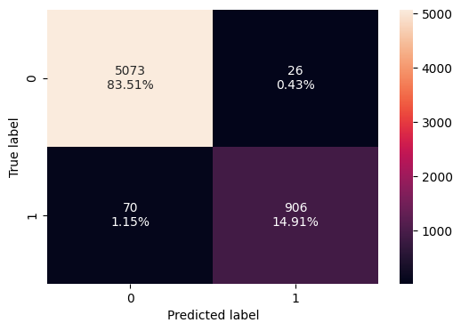

```python
# Creating the confusion matrix for the tuned model's performance on the original training data.
confusion_matrix_sklearn(XGB_org_tuned, X_train, y_train)
```

```python
# Checking the tuned model's performance metrics on the validation data.
model_performance_classification_sklearn(XGB_org_tuned, X_val, y_val)
```

|  | Accuracy | Recall | Precision | F1 |
| --- | --- | --- | --- | --- |
| 0 | 0.969891 | 0.877301 | 0.931596 | 0.903633 |

```python
# Saving the tuned model's scores for later comparison.
XGB_org_tuned_val_scores = model_performance_classification_sklearn(XGB_org_tuned, X_val, y_val)
```

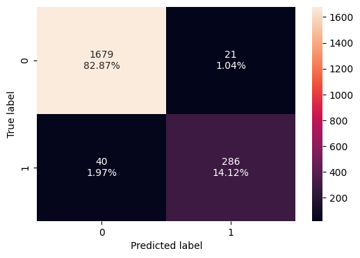

```python
# Creating the confusion matrix for the tuned model's performance on the validation data.
confusion_matrix_sklearn(XGB_org_tuned, X_val, y_val)
```

**The XGBoost performs well compared to other models with Accuracy 98%, recall 92.8%, Precision 97% and f1 score 94.9%**

**The best hyper parameters used are number of estimators 100, learning rate is 0.01, gamma is 3 and cv score is o.9**

**Gradient Boosting with Original data**

```python
# Defining the model.
GBC_org = GradientBoostingClassifier(random_state=1)

# Creating the parameter grid to pass in RandomSearchCV.
param_grid={"init": [AdaBoostClassifier(random_state=1),DecisionTreeClassifier(random_state=1)],
            "n_estimators": np.arange(50,110,25),
            "learning_rate": [0.01,0.1,0.05],
            "subsample":[0.7,0.9],
            "max_features":[0.5,0.7,1],
}
# Defining the scorer.
scorer = make_scorer(precision_score)

# Calling RandomizedSearchCV.
randomized_cv = RandomizedSearchCV(estimator=GBC_org, param_distributions=param_grid, n_iter=10, n_jobs = -1, scoring=scorer, cv=5, random_state=1)

# Fitting the parameters in RandomizedSearchCV.
randomized_cv.fit(X_train,y_train)

# Printing the best parameters from from the RandomizedSearchCV.
print("Best parameters are {} with CV score={}:" .format(randomized_cv.best_params_,randomized_cv.best_score_))
```

```
Best parameters are {'subsample': 0.7, 'n_estimators': 50, 'max_features': 1, 'learning_rate': 0.05, 'init': AdaBoostClassifier(random_state=1)} with CV score=0.9559539170506912:
```

**The best hyper parameter is with Number of estimators is 50, max number of features is 1, learning rate is 0.05**

```python
# Creating the tuned model with the best parameters found in RandomizedSearchCV.
GBC_org_tuned = GradientBoostingClassifier(
    random_state=1,
    subsample=0.7,
    n_estimators=100,
    max_features=0.7,
    learning_rate=0.05,
    init=DecisionTreeClassifier(random_state=1))

# Fitting the model to the original training data.
GBC_org_tuned.fit(X_train, y_train)
```

```
GradientBoostingClassifier(init=DecisionTreeClassifier(random_state=1),
                           learning_rate=0.05, max_features=0.7, random_state=1,
                           subsample=0.7)
```

```python
# Checking the tuned model's performance metrics on the original training data.
model_performance_classification_sklearn(GBC_org_tuned, X_train, y_train)
```

|  | Accuracy | Recall | Precision | F1 |
| --- | --- | --- | --- | --- |
| 0 | 1.0 | 1.0 | 1.0 | 1.0 |

```python
# Saving the tuned model's scores for later comparison.
GBC_org_tuned_train_scores = model_performance_classification_sklearn(GBC_org_tuned, X_train, y_train)
```

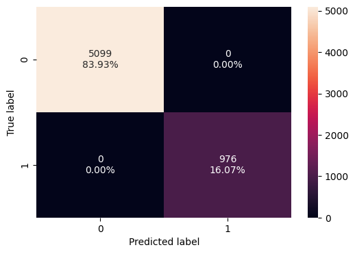

```python
# Creating the confusion matrix for the tuned model's performance on the original training data.
confusion_matrix_sklearn(GBC_org_tuned, X_train, y_train)
```

```python
# Checking the tuned model's performance metrics on the validation data.
model_performance_classification_sklearn(GBC_org_tuned, X_val, y_val)
```

|  | Accuracy | Recall | Precision | F1 |
| --- | --- | --- | --- | --- |
| 0 | 0.939289 | 0.815951 | 0.808511 | 0.812214 |

```python
# Saving the tuned model's scores for later comparison.
GBC_org_tuned_val_scores = model_performance_classification_sklearn(GBC_org_tuned, X_val, y_val)
```

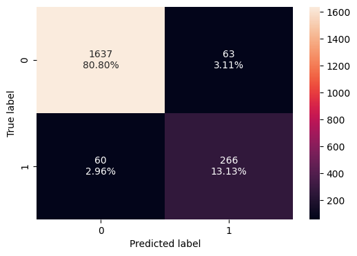

```python
# Creating the confusion matrix for the tuned model's performance on the validation data.
confusion_matrix_sklearn(GBC_org_tuned, X_val, y_val)
```

**The Accuracy in Gradient boost model for original data is 93%, recall is 81%, precision is 80% and F1 Score is 81%**

**The best hyper parameter is with Number of estimators is 50, max number of features is 1, learning rate is 0.05**